# StanとRでベイズ統計モデリング09

UPDATE: 2023-12-26 23:06:56.666156

# はじめに

このノートは「StanとRでベイズ統計モデリング」の内容を写経することで、ベイズ統計への理解を深めていくために作成している。

- [StanとRでベイズ統計モデリング](https://www.kyoritsu-pub.co.jp/bookdetail/9784320112421)
- [StanとRでベイズ統計モデリング サポートページ](https://github.com/MatsuuraKentaro/RStanBook)

基本的には気になった部分を写経しながら、ところどころ自分用の補足をメモすることで、「StanとRでベイズ統計モデリング」を読み進めるための自分用の補足資料になることを目指す。私の解釈がおかしく、メモが誤っている場合があるので注意。

今回は第8章「階層モデル」のチャプターを写経していく。非線形モデルのところから。

## 8.3 非線形モデルの階層モデル

7.3節のモデルを16人に拡張して階層モデルを適用する。

```r
options(max.print = 999999)
library(dplyr)
library(ggplot2)
library(rstan)

d <- read.csv('https://raw.githubusercontent.com/MatsuuraKentaro/RStanBook/master/chap08/input/data-conc-2.txt')
N <- nrow(d)
Time <- c(1, 2, 4, 8, 12, 24)
T_new <- 60
Time_new <- seq(from = 0, to = 24, length = T_new)
data <- list(N = N, T = length(Time), Time = Time, Y = d[,-1],
             T_new = T_new, Time_new = Time_new)

head(d, 10)
```

```
##    PersonID Time1 Time2 Time4 Time8 Time12 Time24
## 1         1   2.4   5.0   7.5  11.9   12.5   12.7
## 2         2   1.4   3.9   4.4   7.7    6.4    8.3
## 3         3   5.2   9.4  19.4  20.2   22.7   24.9
## 4         4   6.7  12.6  19.1  23.4   25.8   26.1
## 5         5   0.3   4.7   7.0  10.2   12.9   14.8
## 6         6   6.3   3.8  11.8   9.2   13.9   18.2
## 7         7   3.0   4.2   8.8  15.4   10.7   16.2
## 8         8   6.2   6.8   9.4  11.3   12.4   14.7
## 9         9  14.4  17.0  22.7  29.8   33.0   32.2
## 10       10   7.7  10.0  14.8  15.3   18.0   18.7
```

## 8.3.1 解析の目的とデータの分布の確認

各個人において、頭打ちになる$Y$の値と、頭打ちになるまでの時間を知りたい。また個人差のばらつきも分析したいとする。各個人のデータを可視化すると、頭打ちになるものの、個人ごとに上限が異なることがわかる。

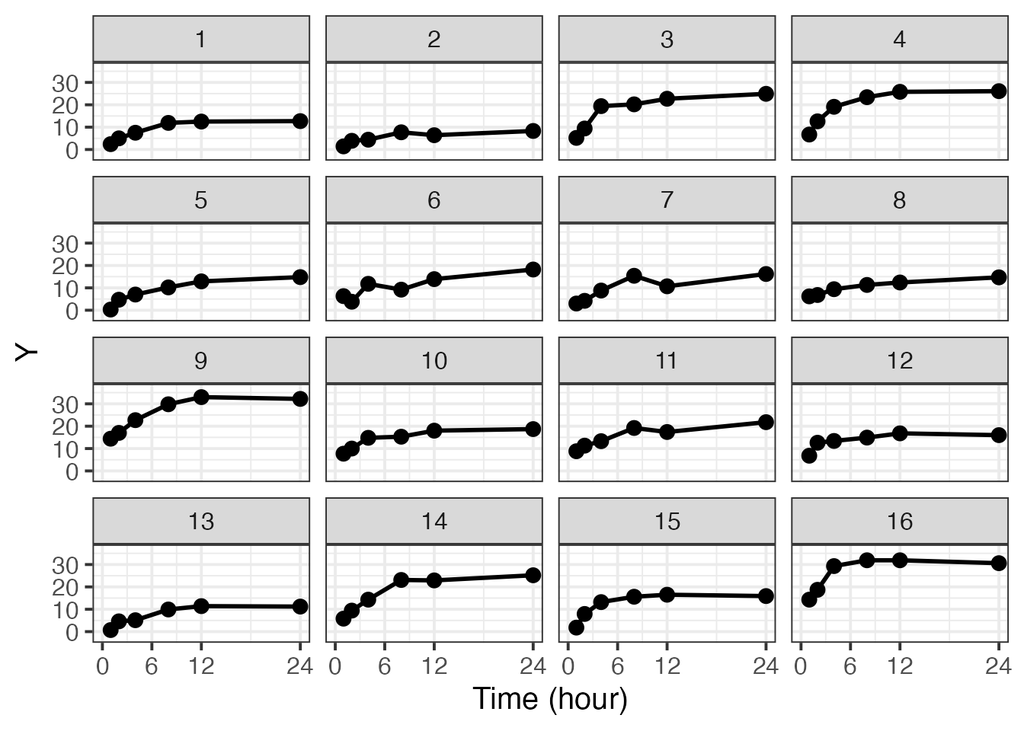

```r
d %>%
  tidyr::pivot_longer(cols = -PersonID, values_to = 'Y') %>%
  mutate(Time = readr::parse_number(name)) %>%
  select(-name) %>%
  ggplot(data = ., aes(x = Time, y = Y)) +
  theme_bw(base_size = 15) +
  facet_wrap(~PersonID) +
  geom_line(linewidth = 1) +
  geom_point(size = 3) +
  labs(x = 'Time (hour)', y = 'Y') +
  scale_x_continuous(breaks = c(0,6,12,24), limit = c(0,24)) +
  scale_y_continuous(breaks = seq(0,40,10), limit = c(-3,37))
```

最終時点ごとの$Y$の値も個人によって異なる。

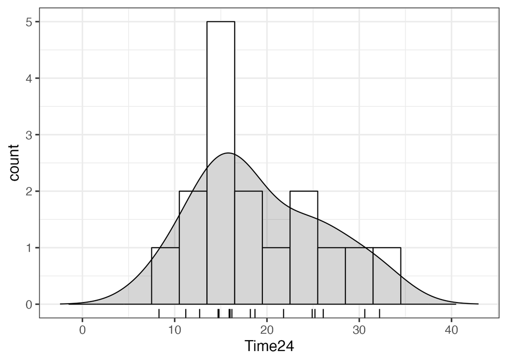

```r
d_last <- d[ncol(d)]

bw <- 3.0
ggplot(data = d_last, aes(x = Time24)) +
  theme_bw(base_size = 15) +
  geom_histogram(binwidth = bw, color = 'black', fill = 'white') +
  geom_density(aes(y = after_stat(count)*bw), alpha = 0.2, color = 'black', fill = 'gray20') +
  geom_rug(sides = 'b') +
  labs(x = 'Time24', y = 'count') +
  xlim(range(density(d_last$Time24)$x))
```

## 8.3.2 メカニズムの想像

ここでは`a[n],b[n]`が特定の分布に従うと仮定して、階層モデルを適用する。`a[n],b[n]`は正の値をとることを考慮し、対数をとった`log(a)[n],log(b)[n]`が正規分布に従うと仮定する。考えるだけで、`log`はとってないので注意。

## 8.3.3 モデル式の記述

ここで想定しているモデルは下記の通り。

モデル8-7

$$\begin{eqnarray}
Y[n,t] &\sim& Normal(a[n]\{1 -\exp(-b[n] Time[t]) \},
\sigma_{Y}) \\
log(a[n]) &\sim& Normal(a_{全体平均}, \sigma_{a}) \\
log(b[n]) &\sim& Normal(b_{全体平均}, \sigma_{b})
\end{eqnarray}$$

データから$\sigma_{Y}, a[n], a_{全体平均}, \sigma_{a}, b[n], b_{全体平均}, \sigma_{b}$を推定する。

## 8.3.4 Stanで実装

Stanファイルは下記の通り。

```
data {
  int N;
  int T;
  real Time[T];
  real Y[N,T];
  int T_new;
  real Time_new[T_new];
}

parameters {
  real a0;
  real b0;
  real log_a[N];
  real log_b[N];
  real<lower=0> s_a;
  real<lower=0> s_b;
  real<lower=0> s_Y;
}

transformed parameters {
  real a[N];
  real b[N];
  for (n in 1:N) {
  // expは、logはとってないが想定する値がマイナスにならないようにする.
  // `a[n],b[n]`は正の値をとることを考慮
    a[n] = exp(log_a[n]);
    b[n] = exp(log_b[n]);
  }
}

model {
  for (n in 1:N) {
    // logはとってない、対数をとったものが正規分布に従うと考える
    log_a[n] ~ normal(a0, s_a);
    log_b[n] ~ normal(b0, s_b);
  }
  for (n in 1:N)
    for (t in 1:T)
      Y[n,t] ~ normal(a[n]*(1 - exp(-b[n]*Time[t])), s_Y);
}

generated quantities {
  real y_new[N,T_new];
  for (n in 1:N)
    for (t in 1:T_new)
      y_new[n,t] = normal_rng(a[n]*(1 - exp(-b[n]*Time_new[t])), s_Y);
}
```

ここでは、`stan_model()`関数で最初にコンパイルしておいてから、

```r
model87 <- stan_model('note_ahirubayes09-87.stan')
```

`sampling()`関数でサンプリングする。

```r
fit <- sampling(object = model87, data = data, seed = 1989)
```

パラメタの推定結果はこちら。$\sigma_{Y}$以外は対数スケールとなっている。少し混乱するが、`a[1],b[1]`は通常スケールで`exp`で変換する前の`a0,b0`が対数スケールということ(対数変換したものが正規分布に従うと考えている)。

```r
print(fit, prob = c(0.025, 0.5, 0.975), digits_summary = 1)
```

```
## Inference for Stan model: anon_model.
## 4 chains, each with iter=2000; warmup=1000; thin=1;
## post-warmup draws per chain=1000, total post-warmup draws=4000.
##
##               mean se_mean  sd  2.5%   50% 97.5% n_eff Rhat
## a0             2.9     0.0 0.1   2.6   2.9   3.1  4986    1
## b0            -1.2     0.0 0.1  -1.4  -1.2  -0.9  3387    1
## log_a[1]       2.6     0.0 0.1   2.4   2.6   2.8  4154    1
## log_a[2]       2.1     0.0 0.1   1.8   2.1   2.4  4509    1
## log_a[3]       3.2     0.0 0.1   3.1   3.2   3.3  5360    1
## log_a[4]       3.3     0.0 0.0   3.2   3.3   3.3  4168    1
## log_a[5]       2.6     0.0 0.1   2.4   2.6   2.9  3789    1
## log_a[6]       2.7     0.0 0.1   2.6   2.7   2.9  3439    1
## log_a[7]       2.7     0.0 0.1   2.5   2.7   2.9  5375    1
## log_a[8]       2.6     0.0 0.1   2.4   2.6   2.8  4394    1
## log_a[9]       3.5     0.0 0.0   3.4   3.5   3.5  5042    1
## log_a[10]      2.9     0.0 0.1   2.8   2.9   3.0  5028    1
## log_a[11]      3.0     0.0 0.1   2.9   3.0   3.1  5627    1
## log_a[12]      2.8     0.0 0.1   2.7   2.8   2.9  4754    1
## log_a[13]      2.4     0.0 0.1   2.2   2.4   2.7  4070    1
## log_a[14]      3.2     0.0 0.1   3.1   3.2   3.3  4718    1
## log_a[15]      2.8     0.0 0.1   2.7   2.8   2.9  5345    1
## log_a[16]      3.5     0.0 0.0   3.4   3.5   3.5  5109    1
## log_b[1]      -1.4     0.0 0.2  -1.9  -1.4  -0.9  3756    1
## log_b[2]      -1.4     0.0 0.3  -2.1  -1.3  -0.7  3831    1
## log_b[3]      -1.2     0.0 0.2  -1.5  -1.2  -0.9  5122    1
## log_b[4]      -1.1     0.0 0.1  -1.4  -1.1  -0.9  4526    1
## log_b[5]      -1.6     0.0 0.3  -2.2  -1.6  -1.1  2992    1
## log_b[6]      -1.4     0.0 0.3  -2.0  -1.4  -0.9  3293    1
## log_b[7]      -1.4     0.0 0.2  -1.9  -1.4  -1.0  3942    1
## log_b[8]      -1.1     0.0 0.3  -1.6  -1.1  -0.5  5038    1
## log_b[9]      -0.9     0.0 0.1  -1.2  -0.9  -0.7  4715    1
## log_b[10]     -0.9     0.0 0.2  -1.3  -0.9  -0.5  4343    1
## log_b[11]     -1.0     0.0 0.2  -1.4  -1.0  -0.6  4759    1
## log_b[12]     -0.7     0.0 0.2  -1.1  -0.7  -0.2  4411    1
## log_b[13]     -1.5     0.0 0.3  -2.1  -1.5  -0.9  3733    1
## log_b[14]     -1.4     0.0 0.2  -1.7  -1.4  -1.1  4292    1
## log_b[15]     -1.2     0.0 0.2  -1.5  -1.2  -0.8  5784    1
## log_b[16]     -0.7     0.0 0.1  -0.9  -0.7  -0.4  4909    1
## s_a            0.4     0.0 0.1   0.3   0.4   0.6  4460    1
```

[output cut: 985 more lines]

```
## y_new[16,52]  31.9     0.0 2.0  27.9  31.9  35.8  4244    1
## y_new[16,53]  31.8     0.0 2.0  27.8  31.8  35.9  4591    1
## y_new[16,54]  31.9     0.0 2.0  28.0  31.8  35.9  4085    1
## y_new[16,55]  31.9     0.0 2.0  28.0  31.9  35.8  4374    1
## y_new[16,56]  31.9     0.0 2.0  28.1  31.9  35.6  4451    1
## y_new[16,57]  31.9     0.0 2.0  28.0  31.8  35.7  4267    1
## y_new[16,58]  31.8     0.0 2.0  27.9  31.9  35.8  4317    1
## y_new[16,59]  31.9     0.0 2.0  28.0  31.9  35.9  4338    1
## y_new[16,60]  31.8     0.0 2.0  27.9  31.8  35.8  4435    1
## lp__         -85.0     0.2 5.3 -96.9 -84.6 -76.0  1100    1
##
## Samples were drawn using NUTS(diag_e) at Tue Dec 26 23:07:23 2023.
## For each parameter, n_eff is a crude measure of effective sample size,
## and Rhat is the potential scale reduction factor on split chains (at
## convergence, Rhat=1).
```

MCMCで得られたデータを利用して予測分布を可視化する。

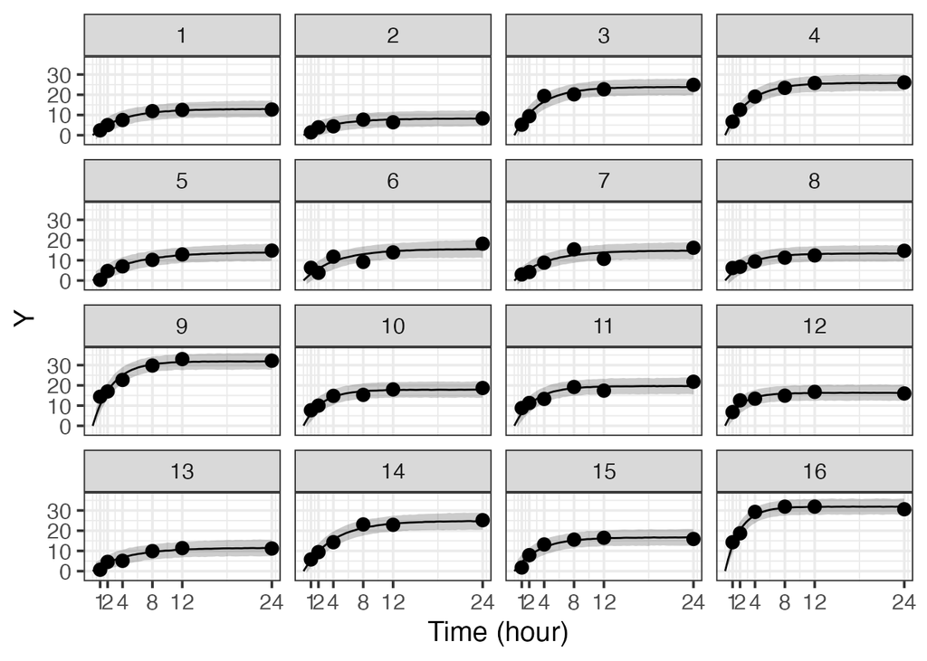

```r
ms <- rstan::extract(fit)
d_est <- data.frame()
for (n in 1:nrow(d)) {
  qua <- apply(ms$y_new[,n,], 2, quantile, prob  =  c(0.025, 0.5, 0.975))
  d_est <- rbind(d_est, data.frame(PersonID = n, Time = Time_new, t(qua), check.names = FALSE))
}

d2 <- d %>%
  tidyr::pivot_longer(cols = -PersonID, values_to = 'Y') %>%
  mutate(Time = readr::parse_number(name)) %>%
  select(-name)

ggplot(data = d_est, aes(x = Time, y = `50%`)) +
  theme_bw(base_size = 15) +
  facet_wrap(~PersonID) +
  geom_ribbon(aes(ymin = `2.5%`, ymax = `97.5%`), fill = 'black', alpha = 1/5) +
  geom_line(linewidth = 0.5) +
  geom_point(data = d2, aes(x = Time, y = Y), size = 3) +
  labs(x = 'Time (hour)', y = 'Y') +
  scale_x_continuous(breaks = Time, limit = c(0,24)) +
  scale_y_continuous(breaks = seq(0,40,10), limit = c(-3,37))
```

## ガンマ分布を利用したモデル

書籍と同じようなモデルとして、ガンマ分布を利用する方法もある。ガンマ分布は正の値しかとらないので、今回のケースでは都合よい。Stanで使用する際はパラメタを$\alpha = \frac{\mu^2}{\sigma},\beta=\frac{\mu}{\sigma}$と指定するので注意。

- [Stanでガンマ回帰（動かす編）](https://messefor.hatenablog.com/entry/2020/09/05/232031)
- [16.6 Gamma Distribution](https://mc-stan.org/docs/2_21/functions-reference/gamma-distribution.html)

ガンマ分布を使った場合のStanのモデルは下記のように表現できる。

```
data {
  int N;
  int T;
  real Time[T];
  real Y[N,T];
  int T_new;
  real Time_new[T_new];
}

parameters {
  real mu_a;
  real mu_b;
  real<lower=0> a[N];
  real<lower=0> b[N];
  real<lower=0> s_a;
  real<lower=0> s_b;
  real<lower=0> s_Y;
}

model {
  for (n in 1:N) {
    a[n] ~ gamma(mu_a^2/s_a, mu_a/s_a);
    b[n] ~ gamma(mu_b^2/s_b, mu_b/s_b);
  }
  for (n in 1:N)
    for (t in 1:T)
      Y[n,t] ~ normal(a[n]*(1 - exp(-b[n]*Time[t])), s_Y);
}

generated quantities {
  real y_new[N,T_new];
  for (n in 1:N)
    for (t in 1:T_new)
      y_new[n,t] = normal_rng(a[n]*(1 - exp(-b[n]*Time_new[t])), s_Y);
}
```

ここでは、`stan_model()`関数で最初にコンパイルしておいてから、

```r
model87_ <- stan_model('note_ahirubayes09-87_.stan')
```

`sampling()`関数でサンプリングする。

```r
fit_ <- sampling(object = model87_, data = data, seed = 1989)
```

```r
print(fit_, prob = c(0.025, 0.5, 0.975), digits_summary = 1)
```

```
## Inference for Stan model: anon_model.
## 4 chains, each with iter=2000; warmup=1000; thin=1;
## post-warmup draws per chain=1000, total post-warmup draws=4000.
##
##                mean se_mean   sd   2.5%    50%  97.5% n_eff Rhat
## mu_a           19.8     0.0  2.4   15.7   19.5   25.2  2831    1
## mu_b            0.3     0.0  0.0    0.3    0.3    0.5  2621    1
## a[1]           13.0     0.0  1.3   10.7   12.9   15.7  5059    1
## a[2]            8.2     0.0  1.3    6.0    8.1   10.9  3736    1
## a[3]           23.9     0.0  1.2   21.6   23.8   26.2  5757    1
## a[4]           25.9     0.0  1.2   23.7   25.9   28.2  5563    1
## a[5]           14.4     0.0  1.7   11.3   14.3   18.3  3341    1
## a[6]           15.8     0.0  1.7   13.0   15.6   19.5  3519    1
## a[7]           14.9     0.0  1.4   12.3   14.8   17.9  4351    1
## a[8]           13.4     0.0  1.2   11.2   13.3   15.8  4591    1
## a[9]           31.8     0.0  1.1   29.7   31.8   34.1  4271    1
## a[10]          17.9     0.0  1.1   15.8   17.8   19.9  5847    1
## a[11]          19.6     0.0  1.1   17.5   19.6   22.0  5398    1
## a[12]          16.3     0.0  1.0   14.5   16.3   18.3  4894    1
## a[13]          11.6     0.0  1.4    9.1   11.5   14.7  3719    1
## a[14]          24.9     0.0  1.3   22.3   24.8   27.6  5407    1
## a[15]          16.7     0.0  1.1   14.5   16.6   19.0  5550    1
## a[16]          31.9     0.0  1.0   29.9   31.9   33.9  4874    1
## b[1]            0.3     0.0  0.1    0.2    0.3    0.4  5126    1
## b[2]            0.3     0.0  0.1    0.1    0.3    0.5  4559    1
## b[3]            0.3     0.0  0.0    0.2    0.3    0.4  5370    1
## b[4]            0.3     0.0  0.0    0.2    0.3    0.4  4901    1
## b[5]            0.2     0.0  0.1    0.1    0.2    0.3  3548    1
## b[6]            0.2     0.0  0.1    0.1    0.2    0.4  3885    1
## b[7]            0.2     0.0  0.1    0.1    0.2    0.4  5023    1
## b[8]            0.4     0.0  0.1    0.2    0.4    0.6  4128    1
## b[9]            0.4     0.0  0.1    0.3    0.4    0.5  4639    1
## b[10]           0.4     0.0  0.1    0.3    0.4    0.6  4383    1
## b[11]           0.4     0.0  0.1    0.3    0.4    0.6  5570    1
## b[12]           0.5     0.0  0.1    0.3    0.5    0.8  3984    1
## b[13]           0.2     0.0  0.1    0.1    0.2    0.4  3792    1
## b[14]           0.3     0.0  0.0    0.2    0.2    0.3  4833    1
## b[15]           0.3     0.0  0.1    0.2    0.3    0.5  4774    1
## b[16]           0.5     0.0  0.1    0.4    0.5    0.6  4418    1
## s_a            78.7     1.2 54.6   28.2   64.8  210.1  1926    1
```

[output cut: 953 more lines]

```
## y_new[16,52]   31.8     0.0  2.0   27.9   31.8   35.7  4045    1
## y_new[16,53]   31.9     0.0  2.0   28.0   31.9   35.8  4316    1
## y_new[16,54]   31.9     0.0  2.0   27.8   31.9   35.8  4513    1
## y_new[16,55]   31.9     0.0  2.0   27.9   31.9   35.8  3886    1
## y_new[16,56]   31.9     0.0  2.0   27.9   31.9   35.9  4442    1
## y_new[16,57]   31.8     0.0  2.0   27.9   31.8   35.8  4257    1
## y_new[16,58]   31.8     0.0  2.0   27.8   31.8   35.8  4555    1
## y_new[16,59]   31.8     0.0  2.0   27.9   31.8   35.6  4135    1
## y_new[16,60]   31.9     0.0  2.0   27.9   31.9   36.0  3969    1
## lp__         -113.6     0.1  5.3 -125.1 -113.1 -104.5  1259    1
##
## Samples were drawn using NUTS(diag_e) at Tue Dec 26 23:07:53 2023.
## For each parameter, n_eff is a crude measure of effective sample size,
## and Rhat is the potential scale reduction factor on split chains (at
## convergence, Rhat=1).
```

MCMCで得られたデータを利用して予測分布を可視化する。

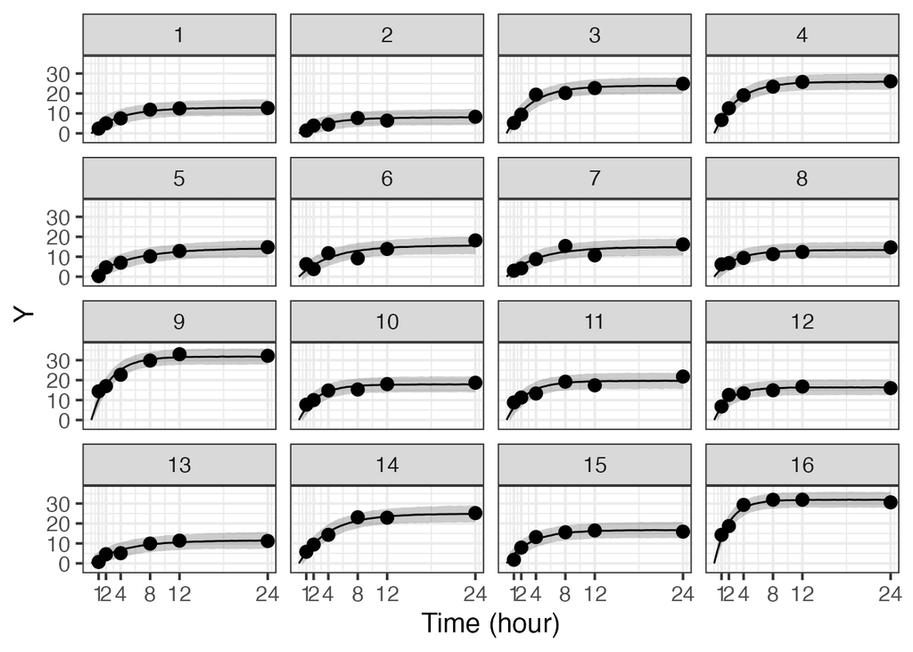

```r
ms <- rstan::extract(fit_)
d_est <- data.frame()
for (n in 1:nrow(d)) {
  qua <- apply(ms$y_new[,n,], 2, quantile, prob = c(0.025, 0.5, 0.975))
  d_est <- rbind(d_est, data.frame(PersonID = n, Time = Time_new, t(qua), check.names = FALSE))
}

ggplot(data = d_est, aes(x = Time, y = `50%`)) +
  theme_bw(base_size = 15) +
  facet_wrap(~PersonID) +
  geom_ribbon(aes(ymin = `2.5%`, ymax = `97.5%`), fill = 'black', alpha = 1/5) +
  geom_line(linewidth = 0.5) +
  geom_point(data = d2, aes(x = Time, y = Y), size = 3) +
  labs(x = 'Time (hour)', y = 'Y') +
  scale_x_continuous(breaks = Time, limit = c(0,24)) +
  scale_y_continuous(breaks = seq(0,40,10), limit = c(-3,37))
```

## 参考文献および参考資料

- [StanとRでベイズ統計モデリング](https://www.kyoritsu-pub.co.jp/bookdetail/9784320112421)
- [StanとRでベイズ統計モデリング サポートページ](https://github.com/MatsuuraKentaro/RStanBook)
- [Stan Reference Manual](https://mc-stan.org/docs/reference-manual/index.html)